# T8

### TCX3212 Predictive Analytics

### Tutorial/Lab 9

Learning Objectives

- Understand and Apply Exponential Smoothing
- Understand and Apply Holt-Winters Forecasting
- Evaluate forecast accuracy

```python
# 1. Import libraries
import pandas as pd
import matplotlib.pyplot as plt
from statsmodels.tsa.holtwinters import ExponentialSmoothing

%matplotlib inline
plt.rcParams["figure.figsize"] = (12, 6)
```

```python
# In JupyterLab, first navigate to the directory containing College.csv
# import os
# os.chdir('C:/Users/sowjs/NUS Dropbox/Jin Sze Sow/Jin Sze Sow’s files/Home/BIT TCX 3212 Predictive Analytics/AY2526S2/Tutorial/T9')  # Replace with your actual path
```

#### Simple Exponential Smoothing

1. In this exercise, you will analyze and forecast annual oil production in Saudi Arabia using Simple Exponential Smoothing (SES).

a) Load Oil.csv and convert the Year column to a datetime format. Set it as the index and create a pandas Series with a yearly frequency. Plot the original time series. Describe any trends or patterns you notice in the data.

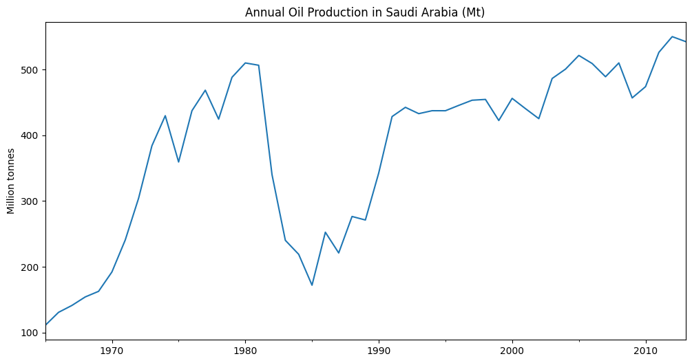

```python
# Assume oil.csv has two columns: "Year" and "Production"
oil_df = pd.read_csv("./Oil.csv")

# Convert 'Year' to datetime and set as index
oil_df["Year"] = pd.to_datetime(oil_df["Year"], format="%Y")
oil_df.set_index("Year", inplace=True)

# Create a pandas Series
oil = oil_df["Production"]

# Create pandas Series with yearly frequency
oil = pd.Series(oil, index=pd.date_range("1965", "2013", freq="YS"))

# Plot original data
oil.plot(title="Annual Oil Production in Saudi Arabia (Mt)")
plt.ylabel("Million tonnes")
plt.show()
```

b) Fit a Simple Exponential Smoothing (SES) model to the data. Experiment with different smoothing levels (e.g., α = 0.2, α = 0.5, α = 0.8). Plot the fitted values for each α on the same graph and compare them. Discuss how changing α affects the smoothness of the series and the responsiveness to recent trends.

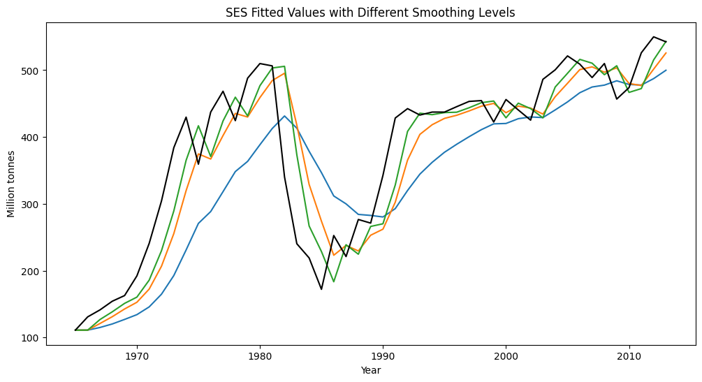

```python
from statsmodels.tsa.holtwinters import SimpleExpSmoothing

alphas = [0.2, 0.5, 0.8]
fitted_values = {}

plt.figure(figsize=(12, 6))
for alpha in alphas:
    ses_model = SimpleExpSmoothing(oil).fit(smoothing_level=alpha, optimized=False)
    fitted_values[alpha] = ses_model.fittedvalues
    plt.plot(ses_model.fittedvalues, label=f"α={alpha})")

plt.plot(oil, label="Original Data", color="black")
plt.title("SES Fitted Values with Different Smoothing Levels")
plt.xlabel("Year")
plt.ylabel("Million tonnes")
```

c) Using α = 0.9, generate a 5-year forecast.

```python
ses_model = SimpleExpSmoothing(oil).fit(smoothing_level=0.9, optimized=False)

## Convert integer years to a PeriodIndex with annual frequency
if not isinstance(oil.index, (pd.DatetimeIndex, pd.PeriodIndex)):
    oil.index = pd.PeriodIndex(oil.index, freq="A")

## Generate a 5 year forecast
ses_forecast = ses_model.forecast(5)
print(ses_forecast)

fitted_values = ses_model.fittedvalues
print("")

# Print with year if index is annual
for year, value in fitted_values.items():
    print(f"{year.year}, Fitted: {value:.2f}")
```

```
2014-01-01    542.79767
2015-01-01    542.79767
2016-01-01    542.79767
2017-01-01    542.79767
2018-01-01    542.79767
Freq: YS-JAN, dtype: float64

1965, Fitted: 111.01
1966, Fitted: 111.01
1967, Fitted: 128.85
1968, Fitted: 140.04
1969, Fitted: 152.81
1970, Fitted: 161.75
1971, Fitted: 189.12
1972, Fitted: 235.63
```

[output cut: 41 more lines]

d) Calculate the RMSE between the fitted values and the actual data for each α. Which α gives the lowest error? Does the lowest RMSE always correspond to the “best” forecast visually? Explain.

```python
from sklearn.metrics import mean_squared_error
import numpy as np

alphas = [0.2, 0.5, 0.8]
rmse_values = {}

for alpha in alphas:
    ses_model = SimpleExpSmoothing(oil).fit(smoothing_level=alpha, optimized=False)
    fitted = ses_model.fittedvalues
    rmse = np.sqrt(mean_squared_error(oil, fitted))
    rmse_values[alpha] = rmse
    print(f"α={alpha}, RMSE: {rmse:.2f}")

print("")
print(rmse_values)
```

```
α=0.2, RMSE: 90.36
α=0.5, RMSE: 62.16
α=0.8, RMSE: 51.14

{0.2: np.float64(90.36209039724527), 0.5: np.float64(62.15778392244679), 0.8: np.float64(51.13987791473321)}
```

#### Holt-winter Forecasting

2. In this exercise, you will load, visualize, and analyze a quarterly time series of Australian tourist arrivals from March 1999 – Dec 2015. You will perform decomposition to understand trends, seasonality, and select an appropriate model for forecasting. You will be using the Austourists (Austourists.csv) data set which can be downloaded from Canvas.

a) Load Austourists.csv, convert Date column to datetime. Set the Date column as the index and ensure it has a quarterly frequency and plot the time series. Describe the observed trend and seasonal patterns.

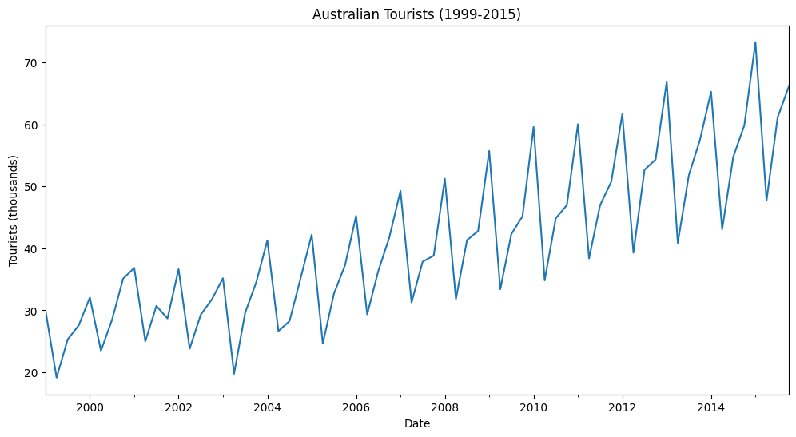

```python
import pandas as pd
import matplotlib.pyplot as plt
from statsmodels.tsa.seasonal import seasonal_decompose

# Load your data
austourists_df = pd.read_csv("./Austourists.csv")
austourists_df["Date"] = pd.to_datetime(austourists_df["Date"], format="%d/%m/%Y")
austourists_df.set_index("Date", inplace=True)

# Ensure the index has a formal Quarterly Frequency (Quarter Start)
austourists = austourists_df["Tourists"].asfreq("QS")
austourists = austourists_df["Tourists"]
austourists.plot(title="Australian Tourists (1999-2015)", ylabel="Tourists (thousands)")
plt.show()
```

b) Decompose the training time series using both additive and multiplicative decomposition methods. Plot the trend, seasonal, and residual components for both. Compare the results and explain which decomposition better fits the data, and why.

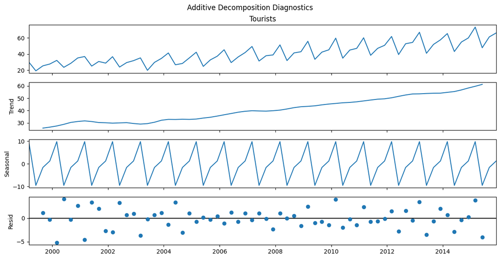

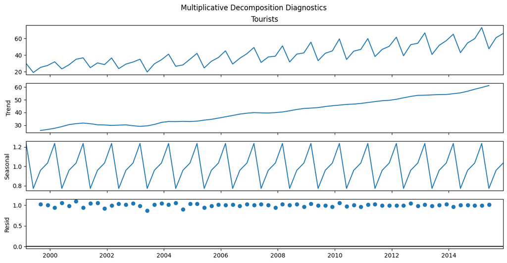

```python
# Perform decomposition, period=4 for quarterly data
decomposition_add = seasonal_decompose(austourists, model="additive")
decomposition_mul = seasonal_decompose(austourists, model="multiplicative")

# Plot additive decomposition
fig_add = decomposition_add.plot()
fig_add.suptitle("Additive Decomposition Diagnostics", fontsize=12, y=1.02)
plt.show()

# Plot multiplicative decomposition
fig_mul = decomposition_mul.plot()
fig_mul.suptitle("Multiplicative Decomposition Diagnostics", fontsize=12, y=1.02)
plt.show()
```

c) Partition the data into a training set and a validation set. Use all data up to December 2014 as the training set and the last four quarters (2015) as the validation set. Explain why it is important to separate the data for training and validation.

```python
# Partitioning the data
train = austourists[:"2014-12-31"]
validation = austourists["2015-01-01":]

print(f"Training observations: {len(train)}")
print(f"Validation observations: {len(validation)}")
```

```
Training observations: 64
Validation observations: 4
```

Why it is important to separate training and validation data:

- Training data is used to fit the model parameters.
- Validation data simulates unseen future data for fair evaluation.
- This helps detect overfitting (good on training, poor on new data).
- It supports objective model/parameter comparison before final forecasting.

```python
from statsmodels.tsa.holtwinters import ExponentialSmoothing
import numpy as np
from sklearn.metrics import mean_squared_error

# Fit Holt-Winters Model (Additive trend and seasonality)
hw_model = ExponentialSmoothing(train, trend="add", seasonal="add", seasonal_periods=4)

# fit the model with the specified parameters
hw_fit = hw_model.fit(
    smoothing_level=0.3,  # Alpha
    smoothing_trend=0.2,  # Beta
    smoothing_seasonal=0.2,  # Gamma
    optimized=False,  # Required to use specified parameters
)
```

e) Generate a forecast for the four quarters of 2015.

```python
forecast_steps = 4
hw_forecast = hw_fit.forecast(forecast_steps)

hw_forecast.index = pd.date_range(start="2015-01-01", periods=forecast_steps, freq="QS")

print("--- 2015 Forecast: ---")
print(hw_forecast)
```

```
--- 2015 Forecast: ---
2015-01-01    68.557037
2015-04-01    46.753329
2015-07-01    57.368926
2015-10-01    60.659064
Freq: QS-JAN, dtype: float64
```

f) Calculate the Root Mean Squared Error (RMSE) for your forecasts and explain what it tells you. Then, calculate the MAPE (Mean Absolute Percentage Error) for each quarter of 2015 and interpret the results.

```python
from sklearn.metrics import mean_squared_error

rmse = np.sqrt(mean_squared_error(validation, hw_forecast))
print(f"Validation RMSE: {rmse:.2f}")
```

```
Validation RMSE: 4.06
```

```python
quarterly_analysis = pd.DataFrame(
    {"Actual": validation.values, "Forecast": hw_forecast.values},
    index=["2015 Q1", "2015 Q2", "2015 Q3", "2015 Q4"],
)

# Calculate the Absolute percentage error for each quarter
quarterly_analysis["APE (%)"] = (
    np.abs(
        (quarterly_analysis["Actual"] - quarterly_analysis["Forecast"])
        / quarterly_analysis["Actual"]
    )
    * 100
)

# Output results
print(f"Overall Validation RMSE: {rmse:.2f}")
print("\n--- Individual Quarter Analysis: ---")
print(quarterly_analysis[["Actual", "Forecast", "APE (%)"]])

# Calculate the average APE for overall MAPE
overall_mape = quarterly_analysis["APE (%)"].mean()
print(f"\nOverall MAPE: {overall_mape:.2f}%")
```

```
Overall Validation RMSE: 4.06

--- Individual Quarter Analysis: ---
            Actual   Forecast   APE (%)
2015 Q1  73.257027  68.557037  6.415753
2015 Q2  47.696624  46.753329  1.977697
2015 Q3  61.097768  57.368926  6.103074
2015 Q4  66.055761  60.659064  8.169912

Overall MAPE: 5.67%
```

g) Plot the forecast and the fitted training values against the actual validation data.

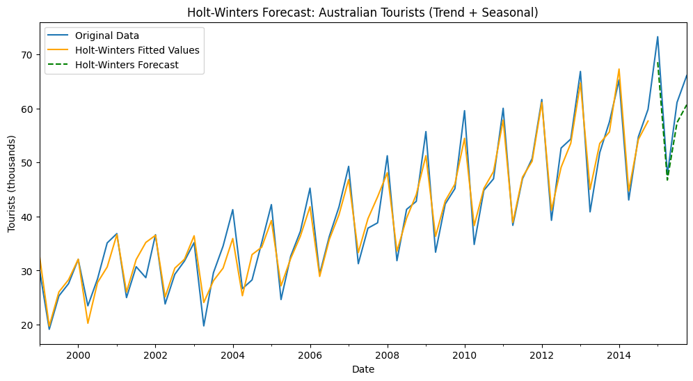

```python
# plot original data, fitted values and forecast
fig, ax = plt.subplots(figsize=(12, 6))
austourists.plot(ax=ax, label="Original Data")
hw_fit.fittedvalues.plot(ax=ax, label="Holt-Winters Fitted Values", color="orange")
hw_forecast.plot(ax=ax, label="Holt-Winters Forecast", color="green", style="--")
ax.set_title("Holt-Winters Forecast: Australian Tourists (Trend + Seasonal)")
ax.set_ylabel("Tourists (thousands)")
ax.legend()
plt.show()
```